# 5-Horse-colic-잠재층 분석

by seung hoon

2020 3 5

데이터 불러오기 3에서 결측값을 대체한 데이터셋을 이용함

```r
library(tidyverse)
new_data = read_csv("C:/Users/SeungSeungSsi/Desktop/기말프로젝트/Horse/horse_data_행렬도.csv")
```

## 5. 잠재층 분석

먼저 outcome(생존여부)가 잠재층이라고 생각하고, 나머지 변수들로 잠재층 분석을 실시했다.  
11

① 공변량을 고려하지 않은 2 클래스 모델의 경우

```r
library(poLCA)
f <- cbind(surgery, age, temp_of_extremities,peripheral_pulse ,mucous_membrane,capillary_refill_time,pain,  peristalsis,surgical_lesion,cp_data ) ~ 1
set.seed(123)
M2 <- poLCA(f, new_data, nclass=2)
```

```
## Conditional item response (column) probabilities,
##  by outcome variable, for each class (row)
##
## $surgery
##            Pr(1)  Pr(2)
## class 1:  0.6145 0.3855
## class 2:  0.2248 0.7752
##
## $age
##            Pr(1)  Pr(2)
## class 1:  0.0687 0.9313
## class 2:  0.0895 0.9105
##
## $temp_of_extremities
##            Pr(1)  Pr(2)  Pr(3)  Pr(4)
## class 1:  0.0448 0.2245 0.4967 0.2340
## class 2:  0.1929 0.6030 0.1625 0.0416
##
## $peripheral_pulse
##            Pr(1)  Pr(2)  Pr(3)  Pr(4)
## class 1:  0.8780 0.0526 0.0695 0.0000
## class 2:  0.1525 0.0121 0.7451 0.0903
##
## $mucous_membrane
##            Pr(1)  Pr(2)  Pr(3)  Pr(4)  Pr(5)  Pr(6)
## class 1:  0.5656 0.1740 0.1951 0.0227 0.0425 0.0000
## class 2:  0.1013 0.0956 0.2171 0.2948 0.1346 0.1565
##
## $capillary_refill_time
##            Pr(1)  Pr(2)
## class 1:  0.9345 0.0655
## class 2:  0.4805 0.5195
##
## $pain
##            Pr(1) Pr(2)  Pr(3) Pr(4)  Pr(5)
## class 1:  0.3393 0.203 0.3930 0.045 0.0197
## class 2:  0.0175 0.259 0.1673 0.265 0.2913
##
## $peristalsis
##            Pr(1)  Pr(2)  Pr(3)  Pr(4)
```

[output cut: 17 more lines]

```
##  0.4348 0.5652
##
## =========================================================
## Fit for 2 latent classes:
## =========================================================
## number of observations: 299
## number of estimated parameters: 47
## residual degrees of freedom: 252
## maximum log-likelihood: -2567.409
##
## AIC(2): 5228.818
## BIC(2): 5402.739
## G^2(2): 1870.378 (Likelihood ratio/deviance statistic)
## X^2(2): 45882.85 (Chi-square goodness of fit)
##
```

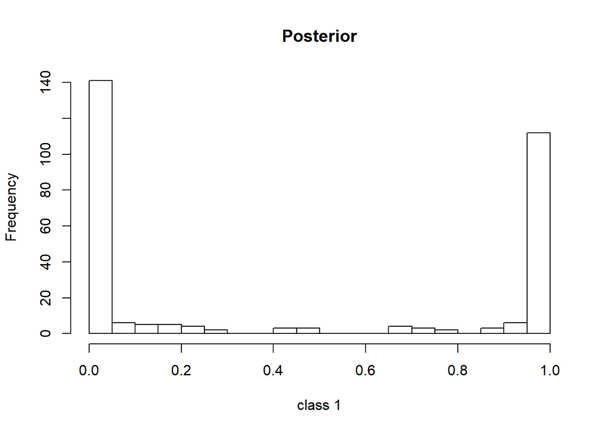

```r
hist(M2$posterior[,1],nclass=20,main="Posterior",xlab="class 1")
```

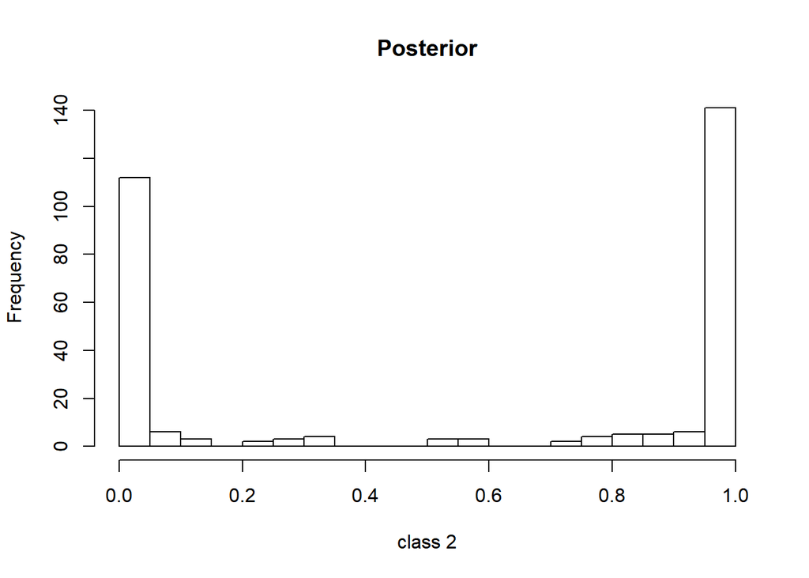

```r
hist(M2$posterior[,2],nclass=20,main="Posterior",xlab="class 2")
```

위와같이 2개의 클래스로 잘 나눠진다는 것을 확인 할 수 있었다.

② 공변량을 고려하지 않은 3 클래스 모델의 경우

```r
library(poLCA)
f <- cbind(surgery, age, temp_of_extremities,peripheral_pulse ,mucous_membrane,capillary_refill_time,pain,  peristalsis,surgical_lesion,cp_data ) ~ 1
set.seed(123)
M3 <- poLCA(f, new_data, nclass=3)
```

```
## Conditional item response (column) probabilities,
##  by outcome variable, for each class (row)
##
## $surgery
##            Pr(1)  Pr(2)
## class 1:  0.2737 0.7263
## class 2:  0.1446 0.8554
## class 3:  0.8195 0.1805
##
## $age
##            Pr(1)  Pr(2)
## class 1:  0.0574 0.9426
## class 2:  0.1262 0.8738
## class 3:  0.0546 0.9454
##
## $temp_of_extremities
##            Pr(1)  Pr(2)  Pr(3)  Pr(4)
## class 1:  0.2771 0.6470 0.0524 0.0235
## class 2:  0.0509 0.4222 0.4032 0.1237
## class 3:  0.0444 0.2115 0.4975 0.2466
##
## $peripheral_pulse
##            Pr(1)  Pr(2)  Pr(3)  Pr(4)
## class 1:  0.0222 0.0194 0.8269 0.1315
## class 2:  0.5819 0.0000 0.4045 0.0136
## class 3:  0.8618 0.0756 0.0626 0.0000
##
## $mucous_membrane
##            Pr(1)  Pr(2)  Pr(3)  Pr(4)  Pr(5)  Pr(6)
## class 1:  0.0264 0.0246 0.1449 0.4188 0.1339 0.2515
## class 2:  0.3435 0.2070 0.2858 0.0659 0.0978 0.0000
## class 3:  0.5823 0.1634 0.1897 0.0206 0.0440 0.0000
##
## $capillary_refill_time
##            Pr(1)  Pr(2)
## class 1:  0.3220 0.6780
## class 2:  0.8268 0.1732
## class 3:  0.9240 0.0760
##
## $pain
```

[output cut: 27 more lines]

```
##  0.3378 0.3579 0.3043
##
## =========================================================
## Fit for 3 latent classes:
## =========================================================
## number of observations: 299
## number of estimated parameters: 71
## residual degrees of freedom: 228
## maximum log-likelihood: -2482.176
##
## AIC(3): 5106.353
## BIC(3): 5369.084
## G^2(3): 1699.913 (Likelihood ratio/deviance statistic)
## X^2(3): 45457.7 (Chi-square goodness of fit)
##
```

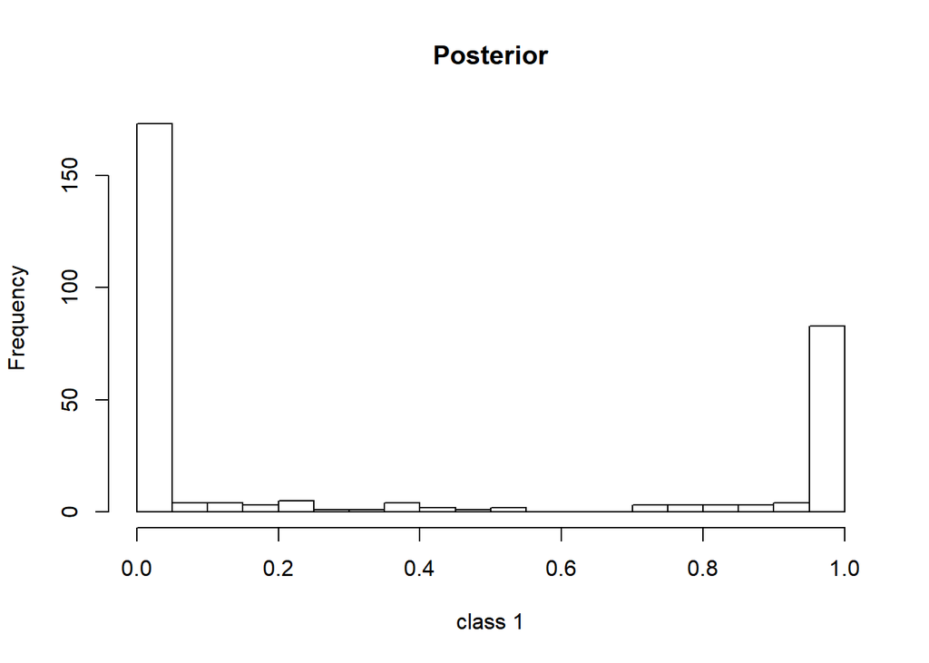

```r
hist(M3$posterior[,1],nclass=20,main="Posterior",xlab="class 1")
```

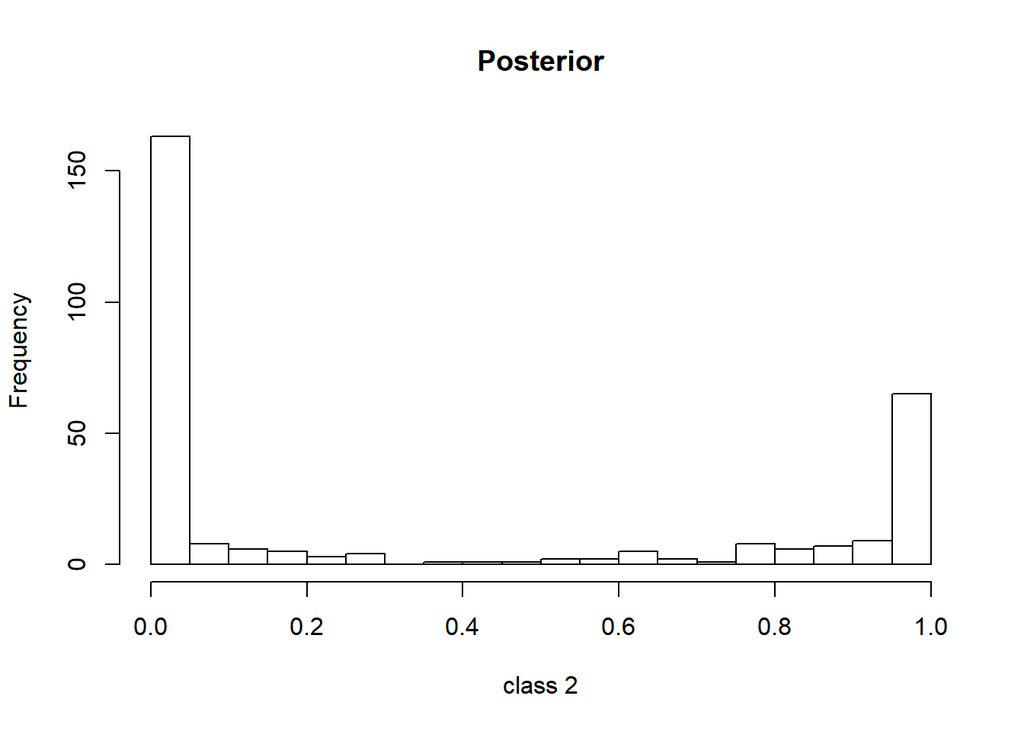

```r
hist(M3$posterior[,2],nclass=20,main="Posterior",xlab="class 2")
```

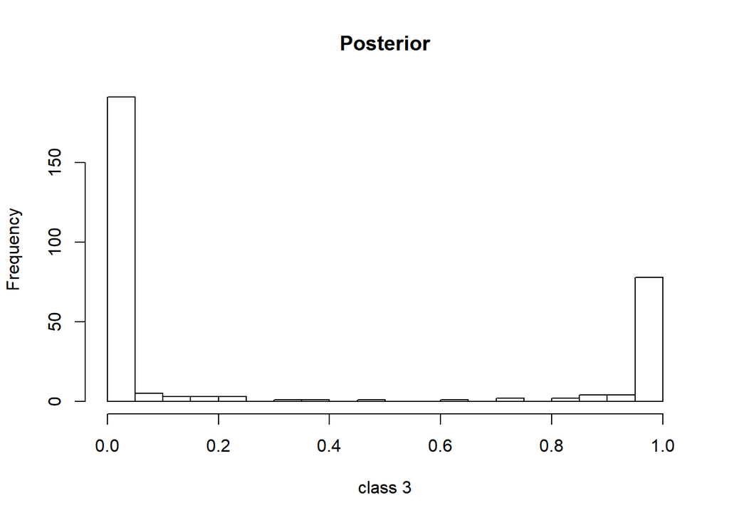

```r
hist(M3$posterior[,3],nclass=20,main="Posterior",xlab="class 3")
```

3개의 클래스 역시 잘 나눠진다는 것을 확인할 수 있었다.

③ 공변량을 추가한 모델

공변량을 추가한 경우 더욱 핏이 좋아짐을 확인할 수 있었다. 그리고 그 중에서도 가장 좋은 핏은 공변량 pulse + packed_cell_volume + respiratory_rate를 추가한 3 클래스 모델이었다.

```r
library(poLCA)
f <- cbind(surgery, age, temp_of_extremities,peripheral_pulse ,mucous_membrane,capillary_refill_time,pain,  peristalsis,surgical_lesion,cp_data ) ~ pulse + packed_cell_volume +  respiratory_rate
set.seed(1)
M3 <- poLCA(f, new_data, nclass=3)
```

```
## Conditional item response (column) probabilities,
##  by outcome variable, for each class (row)
##
## $surgery
##            Pr(1)  Pr(2)
## class 1:  0.7926 0.2074
## class 2:  0.1355 0.8645
## class 3:  0.2981 0.7019
##
## $age
##            Pr(1)  Pr(2)
## class 1:  0.0397 0.9603
## class 2:  0.1340 0.8660
## class 3:  0.0636 0.9364
##
## $temp_of_extremities
##            Pr(1)  Pr(2)  Pr(3)  Pr(4)
## class 1:  0.0445 0.2233 0.4860 0.2463
## class 2:  0.0564 0.4000 0.4190 0.1246
## class 3:  0.2747 0.6654 0.0405 0.0194
##
## $peripheral_pulse
##            Pr(1)  Pr(2)  Pr(3)  Pr(4)
## class 1:  0.8631 0.0743 0.0626 0.0000
## class 2:  0.5767 0.0000 0.3894 0.0339
## class 3:  0.0136 0.0196 0.8539 0.1129
##
## $mucous_membrane
##            Pr(1)  Pr(2)  Pr(3)  Pr(4)  Pr(5) Pr(6)
## class 1:  0.5879 0.1593 0.1898 0.0216 0.0414 0.000
## class 2:  0.3258 0.1992 0.3040 0.0847 0.0863 0.000
## class 3:  0.0304 0.0345 0.1261 0.4047 0.1493 0.255
##
## $capillary_refill_time
##            Pr(1)  Pr(2)
## class 1:  0.9252 0.0748
## class 2:  0.8324 0.1676
## class 3:  0.3063 0.6937
##
## $pain
```

[output cut: 42 more lines]

```
## pulse                  0.06931     0.01655    4.188      0.00
## packed_cell_volume     0.19925     0.04542    4.386      0.00
## respiratory_rate       0.00705     0.02648    0.266      0.79
## =========================================================
## number of observations: 299
## number of estimated parameters: 77
## residual degrees of freedom: 222
## maximum log-likelihood: -2373.27
##
## AIC(3): 4900.541
## BIC(3): 5185.475
## X^2(3): 50404.33 (Chi-square goodness of fit)
##
## ALERT: estimation algorithm automatically restarted with new initial values
##
```

```r
library(vcd)
```

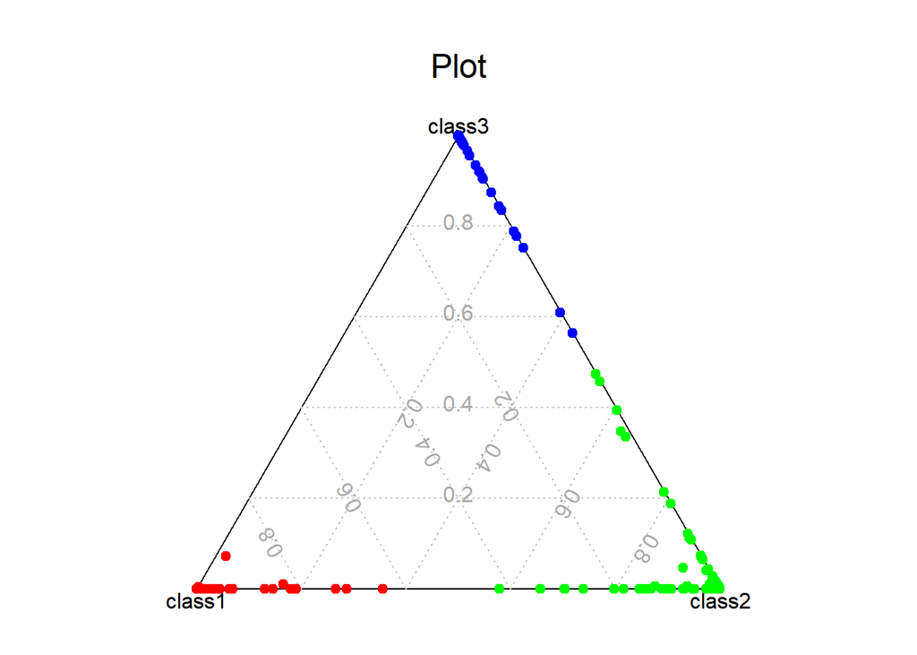

```r
colnames(M3$posterior) <- c("class1","class2","class3")
ternaryplot(M3$posterior, cex=0.5, main="Plot", col=c("red","green","blue")[M3$predclass], )
```

class 2의 경우 class 1와 class 3와의 구별이 상대적으로 덜 뚜렷하다는 것을 확인 할 수 있었다.  
Class1 에서의 예후인자들은 혈류가 정상적이고 고통이 적다고 답하는 등 심각한 정도가 낮다는 것을 알 수 있었다. 또한 Class3에서는 혈류에 심각한 손상을 입었다는 것을 알 수 있었으며, 고통이 있는 편이고 외과적 수술이 필요한 상태라는 것을 알 수 있었다. Class 2은 Class1과 Class 3 에 비해 그 해석이 조금 애매한 편이지만(위의 플롯에서도 확인 가능하다) 건강한 징후는 아니 었다. 따라서 프로젝트 목적에 맞게 조심스럽게 예측을 해보자면 Class 1이 생존이며 Class 3와 Class2 가 사망 또는 안락사가 복합되었다고 예측했다. 하지만 prediected class memberships 의 비율과, 실제 여측하려는 잠재층의 비율(생존/사망/안락사 의 비율) 이 많이 달랐으며, 관련된 도메인의 지식이 부족하여 그 이상의 잠재층 분석은 하지 않았다.